# Machine Learning Approaches to Better Utilize HM450K Data in Cancer Analysis

## Aim 1: Utilize Machine Learning to Determine Tumor State

### Approach 1: Can LLE dimensionality reduction aid in machine learning identification of tumor state?

```python
%load_ext autoreload
%autoreload 2
```

```python
import json
import multiprocessing
import os
import pprint

import numpy as np
import optuna
import pandas as pd
import seaborn as sns
import shap
from matplotlib import pyplot as plt
from sklearn.impute import SimpleImputer
from sklearn.linear_model import LogisticRegression
from sklearn.manifold import LocallyLinearEmbedding
from sklearn.metrics import (ConfusionMatrixDisplay, PrecisionRecallDisplay,
                             RocCurveDisplay, classification_report,
                             confusion_matrix)
from sklearn.model_selection import RandomizedSearchCV, cross_val_score
from sklearn.pipeline import Pipeline
from utils import (RANDOM_STATE, get_tumor_normal_ml_data,
                   stratified_train_test_split)
```

```python
ip = get_ipython()
path = None
if "__vsc_ipynb_file__" in ip.user_ns:
    path = ip.user_ns["__vsc_ipynb_file__"]

currfile = os.path.splitext(os.path.basename(path))[0]
currfile
```

```
'02_dim_red_prediction'
```

#### Load and prep the data

```python
X, y = get_tumor_normal_ml_data()
```

```python
def prep_data(X, y):
    """
    Prepares the data for machine learning by performing the following steps:
    1. Filters out columns in X that have more than 80% missing values.
    2. Splits the filtered data into training and testing sets using stratified sampling.
    3. Converts the training and testing sets to numpy arrays.
    4. Imputes missing values in the training and testing sets using the mean strategy.
    Parameters:
    X (pd.DataFrame): The feature matrix.
    y (pd.Series): The target vector.
    Returns:
    tuple: A tuple containing:
        - X_filtered (pd.DataFrame): The filtered feature matrix.
        - X_train (np.ndarray): The training feature matrix.
        - X_test (np.ndarray): The testing feature matrix.
        - y_train (np.ndarray): The training target vector.
        - y_test (np.ndarray): The testing target vector.
    """
    X_filtered = X.loc[:, X.isna().mean() < 0.8]
    print(
        "Dropped {N} columns with all NaN values".format(
            N=X.shape[1] - X_filtered.shape[1]
        )
    )
    X_train, X_test, y_train, y_test = stratified_train_test_split(X_filtered, y)
    X_train, X_test, y_train, y_test = (
        X_train.to_numpy(),
        X_test.to_numpy(),
        y_train.to_numpy(),
        y_test.to_numpy(),
    )
    imp = SimpleImputer(strategy="mean")
    X_train = imp.fit_transform(X_train)
    X_test = imp.transform(X_test)
    return X_filtered, X_train, X_test, y_train, y_test
```

```python
X_filtered, X_train, X_test, y_train, y_test = prep_data(X, y)
```

```
Dropped 36814 columns with all NaN values
```

```python
X_filtered
```

| id | cg21870274 | cg08258224 | cg16619049 | cg18147296 | cg13938959 | cg12445832 | cg23999112 | cg11527153 | cg27573606 | cg04195702 | ... | cg26348521 | cg03370490 | cg16974513 | cg23628760 | cg04920704 | cg07236001 | cg27267896 | cg23079702 | cg21073216 | cg22820726 |
| --- | --- | --- | --- | --- | --- | --- | --- | --- | --- | --- | --- | --- | --- | --- | --- | --- | --- | --- | --- | --- | --- |
| TCGA-CH-5748-01A | 0.645758 | 0.656690 | 0.987074 | 0.829817 | 0.765562 | 0.563975 | 0.923610 | 0.902567 | 0.961790 | 0.888071 | ... | 0.910931 | 0.973111 | 0.980881 | 0.939469 | 0.867463 | 0.853483 | 0.909006 | 0.832059 | 0.865772 | 0.926564 |
| TCGA-EJ-5505-01A | 0.870373 | 0.627945 | 0.434555 | 0.741031 | 0.857144 | 0.682411 | 0.920843 | 0.908726 | 0.963588 | 0.938181 | ... | 0.910432 | 0.974415 | 0.976944 | 0.924600 | 0.861252 | 0.920901 | 0.913034 | 0.870088 | 0.836950 | 0.953433 |
| TCGA-CH-5771-01A | 0.654246 | 0.620589 | 0.553659 | 0.672388 | 0.780095 | 0.583021 | 0.907692 | 0.898535 | 0.961951 | 0.917109 | ... | 0.892197 | 0.966635 | 0.978560 | 0.915386 | 0.870033 | 0.837269 | 0.910727 | 0.823006 | 0.812190 | 0.931413 |
| TCGA-EJ-5502-01A | 0.689684 | 0.718724 | 0.561286 | 0.727417 | 0.792205 | 0.601268 | 0.942951 | 0.911031 | 0.967079 | 0.915990 | ... | 0.924589 | 0.978463 | 0.977904 | 0.934070 | 0.913384 | 0.859400 | 0.929054 | 0.842740 | 0.867377 | 0.942014 |
| TCGA-CH-5738-01A | 0.725973 | 0.750501 | 0.490818 | 0.774847 | 0.705349 | 0.395335 | 0.777662 | 0.911745 | 0.967098 | 0.922760 | ... | 0.915244 | 0.966887 | 0.981029 | 0.925079 | 0.872097 | 0.880066 | 0.907857 | 0.855435 | 0.850567 | 0.952393 |
| ... | ... | ... | ... | ... | ... | ... | ... | ... | ... | ... | ... | ... | ... | ... | ... | ... | ... | ... | ... | ... | ... |
| TCGA-E9-A1RD-11A_y | 0.000069 | 0.000079 | 0.000042 | 0.000056 | 0.000069 | 0.000042 | 0.000080 | 0.000082 | 0.000095 | 0.000083 | ... | 0.000090 | 0.000097 | 0.000097 | 0.000094 | 0.000081 | 0.000072 | 0.000083 | 0.000091 | 0.000075 | 0.000088 |
| TCGA-BH-A1FR-11B_y | 0.000073 | 0.000087 | 0.000037 | 0.000055 | 0.000070 | 0.000036 | 0.000083 | 0.000088 | 0.000097 | 0.000092 | ... | 0.000090 | 0.000097 | 0.000097 | 0.000089 | 0.000081 | 0.000072 | 0.000085 | 0.000091 | 0.000086 | 0.000092 |
| TCGA-E9-A1RC-11A_y | 0.000080 | 0.000083 | 0.000030 | 0.000049 | 0.000084 | 0.000075 | 0.000089 | 0.000090 | 0.000095 | 0.000074 | ... | 0.000094 | 0.000096 | 0.000093 | 0.000092 | 0.000079 | 0.000074 | 0.000089 | 0.000086 | 0.000073 | 0.000087 |
| TCGA-BH-A1F8-11B_y | 0.000076 | 0.000082 | 0.000038 | 0.000056 | 0.000079 | 0.000041 | 0.000083 | 0.000087 | 0.000096 | 0.000090 | ... | 0.000089 | 0.000097 | 0.000097 | 0.000095 | 0.000084 | 0.000077 | 0.000090 | 0.000088 | 0.000085 | 0.000093 |
| TCGA-BH-A0B3-11B_y | 0.000083 | 0.000090 | 0.000032 | 0.000065 | 0.000066 | 0.000034 | 0.000088 | 0.000087 | 0.000097 | 0.000090 | ... | 0.000087 | 0.000097 | 0.000098 | 0.000096 | 0.000086 | 0.000081 | 0.000094 | 0.000087 | 0.000091 | 0.000091 |

2733 rows × 238284 columns

```python
X_filtered.shape, y.shape
```

```
((2733, 238284), (2733,))
```

```python
# num_cpus = multiprocessing.cpu_count() // 2
num_cpus = 10
```

#### Hyperparameter tuning

For the LocallyLinearEmbedding model:

- n_components
- n_neighbors
- tol
- max_iter
- hessian_tol

For the LogisticRegression model:

- tol
- l1_ratio
- max_iter

```python
def objective(trial):
    try:
        embedder_n_components = trial.suggest_int(
            "embedder__n_components", 500, 2000, step=250
        )
        embedder_n_neighbors = trial.suggest_int("embedder__n_neighbors", 2, 97, step=5)
        embedder_tol = trial.suggest_float("embedder__tol", 1e-6, 1e-3, log=True)
        embedder_max_iter = trial.suggest_int("embedder__max_iter", 75, 150, step=5)
        embedder_hessian_tol = trial.suggest_float(
            "embedder__hessian_tol", 1e-6, 1e-3, log=True
        )

        classifier_tol = trial.suggest_float("classifier__tol", 1e-6, 1e-3, log=True)
        classifier_l1_ratio = trial.suggest_float("classifier__l1_ratio", 0.0, 1.0)
        classifier_C = trial.suggest_int("classifier__C", 2, 22, step=5)
        classifier_max_iter = trial.suggest_int("classifier__max_iter", 75, 150, step=5)

        pipeline = Pipeline(
            [
                (
                    "embedder",
                    LocallyLinearEmbedding(
                        random_state=RANDOM_STATE,
                        n_jobs=num_cpus,
                        neighbors_algorithm="kd_tree",
                        n_components=embedder_n_components,
                        n_neighbors=embedder_n_neighbors,
                        tol=embedder_tol,
                        max_iter=embedder_max_iter,
                        hessian_tol=embedder_hessian_tol,
                    ),
                ),
                (
                    "classifier",
                    LogisticRegression(
                        random_state=RANDOM_STATE,
                        n_jobs=num_cpus,
                        penalty="elasticnet",
                        solver="saga",
                        class_weight="balanced",
                        tol=classifier_tol,
                        l1_ratio=classifier_l1_ratio,
                        C=classifier_C,
                        max_iter=classifier_max_iter,
                    ),
                ),
            ]
        )

        score = cross_val_score(
            pipeline, X_train, y_train, cv=5, scoring="precision", n_jobs=num_cpus
        )
        return score.mean()
    except Exception as e:
        # print(f"Trial failed due to error: {e}")
        return -np.inf


# If file best_params.json exists, load it
try:
    with open(f"{currfile}.best_params.json", "r") as file:
        best_params = json.load(file)
    results = pd.read_csv(f"{currfile}.hyperparmeter_tuning_results.csv")
except FileNotFoundError:
    study = optuna.create_study(
        sampler=optuna.samplers.RandomSampler(seed=RANDOM_STATE),
        direction="maximize",
        study_name=f"{currfile}_hyperparameter_tuning",
    )
    study.optimize(objective, n_trials=30, n_jobs=num_cpus, show_progress_bar=True)

    best_params = study.best_params
    best_params_serializable = {
        k: int(v) if isinstance(v, np.integer) else v for k, v in best_params.items()
    }

    with open(f"{currfile}.best_params.json", "w") as file:
        json.dump(best_params_serializable, file)

    results = study.trials_dataframe()
    results.to_csv(f"{currfile}.hyperparmeter_tuning_results.csv", index=False)
```

```
[I 2024-12-02 17:30:15,570] A new study created in memory with name: 02_dim_red_prediction_hyperparameter_tuning
```

```
[I 2024-12-02 17:40:05,254] Trial 0 finished with value: 0.9915299268386051 and parameters: {'embedder__n_components': 1250, 'embedder__n_neighbors': 7, 'embedder__tol': 3.5751680588060664e-05, 'embedder__max_iter': 85, 'embedder__hessian_tol': 3.0747816111401103e-06, 'classifier__tol': 0.0005331584…
[I 2024-12-02 17:45:44,575] Trial 2 finished with value: 0.99552876719964 and parameters: {'embedder__n_components': 1000, 'embedder__n_neighbors': 17, 'embedder__tol': 5.0456074069220896e-05, 'embedder__max_iter': 140, 'embedder__hessian_tol': 4.08604954734347e-06, 'classifier__tol': 0.000217160712…
```

```
[I 2024-12-02 17:53:22,895] Trial 3 finished with value: 0.9790398243131394 and parameters: {'embedder__n_components': 1000, 'embedder__n_neighbors': 87, 'embedder__tol': 1.7488012535977552e-05, 'embedder__max_iter': 85, 'embedder__hessian_tol': 5.7564958277772367e-05, 'classifier__tol': 1.168168885…
```

```
[I 2024-12-02 18:21:58,694] Trial 5 finished with value: 0.9961107256923277 and parameters: {'embedder__n_components': 1500, 'embedder__n_neighbors': 27, 'embedder__tol': 8.008430434307387e-05, 'embedder__max_iter': 95, 'embedder__hessian_tol': 0.0001323052835785944, 'classifier__tol': 4.40163494432…
```

```
[I 2024-12-02 18:24:42,977] Trial 7 finished with value: 0.9960482609401742 and parameters: {'embedder__n_components': 1500, 'embedder__n_neighbors': 22, 'embedder__tol': 8.701500742109017e-06, 'embedder__max_iter': 80, 'embedder__hessian_tol': 3.771323579432151e-05, 'classifier__tol': 5.18934323016…
[I 2024-12-02 18:31:04,440] Trial 4 finished with value: -inf and parameters: {'embedder__n_components': 2000, 'embedder__n_neighbors': 87, 'embedder__tol': 0.0001396537852109239, 'embedder__max_iter': 110, 'embedder__hessian_tol': 6.577935951144676e-05, 'classifier__tol': 1.9901012026156783e-06, 'c…
```

```
[I 2024-12-02 18:38:58,283] Trial 8 finished with value: 0.9805011212088776 and parameters: {'embedder__n_components': 750, 'embedder__n_neighbors': 52, 'embedder__tol': 9.708133938312574e-05, 'embedder__max_iter': 150, 'embedder__hessian_tol': 6.422774855197493e-05, 'classifier__tol': 0.00013637950…
```

```
[I 2024-12-02 18:40:18,147] Trial 6 finished with value: 0.9961310239512148 and parameters: {'embedder__n_components': 1500, 'embedder__n_neighbors': 77, 'embedder__tol': 0.0006235193309554143, 'embedder__max_iter': 105, 'embedder__hessian_tol': 1.696781789061856e-05, 'classifier__tol': 1.3952190240…
[I 2024-12-02 18:43:10,974] Trial 1 finished with value: 0.981013606510631 and parameters: {'embedder__n_components': 1000, 'embedder__n_neighbors': 82, 'embedder__tol': 0.0007673264612955162, 'embedder__max_iter': 110, 'embedder__hessian_tol': 7.317280952099083e-06, 'classifier__tol': 7.84722254994…
[I 2024-12-02 18:44:49,031] Trial 9 finished with value: 0.996653832972852 and parameters: {'embedder__n_components': 750, 'embedder__n_neighbors': 82, 'embedder__tol': 2.5255139487249327e-06, 'embedder__max_iter': 100, 'embedder__hessian_tol': 8.810536753402819e-05, 'classifier__tol': 4.39142595254…
[I 2024-12-02 18:49:26,452] Trial 10 finished with value: 0.9811301818378639 and parameters: {'embedder__n_components': 1500, 'embedder__n_neighbors': 37, 'embedder__tol': 9.730413350163e-06, 'embedder__max_iter': 105, 'embedder__hessian_tol': 2.9380563803578698e-06, 'classifier__tol': 3.86487215707…
[I 2024-12-02 18:55:50,072] Trial 11 finished with value: -inf and parameters: {'embedder__n_components': 2000, 'embedder__n_neighbors': 92, 'embedder__tol': 0.0004620741449344143, 'embedder__max_iter': 85, 'embedder__hessian_tol': 0.0001949251351292779, 'classifier__tol': 5.410170691147533e-05, 'cl…
```

```
[I 2024-12-02 19:01:32,881] Trial 12 finished with value: 0.9966525120273289 and parameters: {'embedder__n_components': 1250, 'embedder__n_neighbors': 37, 'embedder__tol': 1.2922288262169595e-06, 'embedder__max_iter': 125, 'embedder__hessian_tol': 1.8499810316436472e-06, 'classifier__tol': 4.3841058…
```

```
[I 2024-12-02 19:02:51,301] Trial 13 finished with value: 0.9892389993392576 and parameters: {'embedder__n_components': 1500, 'embedder__n_neighbors': 2, 'embedder__tol': 1.6048700153924846e-06, 'embedder__max_iter': 105, 'embedder__hessian_tol': 0.00011106608470478358, 'classifier__tol': 7.09296492…
```

```
[I 2024-12-02 19:08:38,095] Trial 14 finished with value: 0.99606569870033 and parameters: {'embedder__n_components': 1250, 'embedder__n_neighbors': 17, 'embedder__tol': 0.00042707569428624033, 'embedder__max_iter': 80, 'embedder__hessian_tol': 1.1415701496601084e-05, 'classifier__tol': 7.2242704565…
```

```
[I 2024-12-02 19:16:05,313] Trial 16 finished with value: 0.9904291572313688 and parameters: {'embedder__n_components': 1000, 'embedder__n_neighbors': 2, 'embedder__tol': 2.398626973079145e-05, 'embedder__max_iter': 145, 'embedder__hessian_tol': 1.649142203181936e-06, 'classifier__tol': 0.0001412941…
```

```
[I 2024-12-02 19:22:05,745] Trial 15 finished with value: 0.9966572418973554 and parameters: {'embedder__n_components': 1000, 'embedder__n_neighbors': 67, 'embedder__tol': 8.84717402796466e-05, 'embedder__max_iter': 130, 'embedder__hessian_tol': 6.569781188279522e-05, 'classifier__tol': 0.0005718087…
[I 2024-12-02 19:26:33,347] Trial 17 finished with value: -inf and parameters: {'embedder__n_components': 1750, 'embedder__n_neighbors': 57, 'embedder__tol': 0.00042460968798392124, 'embedder__max_iter': 130, 'embedder__hessian_tol': 2.9552004367317086e-05, 'classifier__tol': 0.00017612010064547951,…
```

```
[I 2024-12-02 19:33:47,282] Trial 19 finished with value: 0.9840005096296555 and parameters: {'embedder__n_components': 500, 'embedder__n_neighbors': 22, 'embedder__tol': 3.926181042712896e-05, 'embedder__max_iter': 85, 'embedder__hessian_tol': 1.934491107132916e-05, 'classifier__tol': 1.05305553490…
[I 2024-12-02 19:35:59,775] Trial 18 finished with value: 0.9956238254355668 and parameters: {'embedder__n_components': 750, 'embedder__n_neighbors': 42, 'embedder__tol': 0.00010994791811366861, 'embedder__max_iter': 115, 'embedder__hessian_tol': 9.989457605284015e-06, 'classifier__tol': 2.892258119…
```

```
[I 2024-12-02 19:43:47,060] Trial 21 finished with value: 0.9933015914959524 and parameters: {'embedder__n_components': 1250, 'embedder__n_neighbors': 12, 'embedder__tol': 2.020174852967016e-06, 'embedder__max_iter': 95, 'embedder__hessian_tol': 0.0007189310575989227, 'classifier__tol': 0.0002820684…
[I 2024-12-02 19:48:09,356] Trial 20 finished with value: 0.9966302567935248 and parameters: {'embedder__n_components': 750, 'embedder__n_neighbors': 37, 'embedder__tol': 3.104588739595113e-05, 'embedder__max_iter': 125, 'embedder__hessian_tol': 0.00036518347428767564, 'classifier__tol': 0.000121348…
```

```
[I 2024-12-02 19:54:38,871] Trial 22 finished with value: 0.9972390656946157 and parameters: {'embedder__n_components': 1500, 'embedder__n_neighbors': 32, 'embedder__tol': 3.8657725690716875e-05, 'embedder__max_iter': 90, 'embedder__hessian_tol': 1.8395941389954677e-06, 'classifier__tol': 2.79628159…
[I 2024-12-02 20:02:33,847] Trial 23 finished with value: -inf and parameters: {'embedder__n_components': 1750, 'embedder__n_neighbors': 97, 'embedder__tol': 7.789225449850435e-06, 'embedder__max_iter': 115, 'embedder__hessian_tol': 1.7776410933579483e-06, 'classifier__tol': 1.3850595367528147e-05, …
[I 2024-12-02 20:07:47,722] Trial 24 finished with value: 0.981024728963248 and parameters: {'embedder__n_components': 500, 'embedder__n_neighbors': 52, 'embedder__tol': 1.3938193865614337e-06, 'embedder__max_iter': 115, 'embedder__hessian_tol': 3.708621296024497e-06, 'classifier__tol': 5.7587670018…
[I 2024-12-02 20:12:47,151] Trial 26 finished with value: -inf and parameters: {'embedder__n_components': 1750, 'embedder__n_neighbors': 17, 'embedder__tol': 6.0001847079387743e-05, 'embedder__max_iter': 80, 'embedder__hessian_tol': 0.00016646143508101044, 'classifier__tol': 5.546299085267533e-06, '…
```

```
[I 2024-12-02 20:18:01,142] Trial 27 finished with value: 0.9915379939392945 and parameters: {'embedder__n_components': 750, 'embedder__n_neighbors': 7, 'embedder__tol': 0.00023559691123603257, 'embedder__max_iter': 95, 'embedder__hessian_tol': 0.0004043193085561515, 'classifier__tol': 1.27149559058…
```

```
[I 2024-12-02 20:22:31,484] Trial 25 finished with value: 0.9950133572194757 and parameters: {'embedder__n_components': 500, 'embedder__n_neighbors': 87, 'embedder__tol': 1.7797113605806254e-06, 'embedder__max_iter': 75, 'embedder__hessian_tol': 3.4883240579206728e-06, 'classifier__tol': 0.000222082…
[I 2024-12-02 20:30:03,568] Trial 29 finished with value: -inf and parameters: {'embedder__n_components': 2000, 'embedder__n_neighbors': 52, 'embedder__tol': 0.00019554744642305078, 'embedder__max_iter': 145, 'embedder__hessian_tol': 0.00013863959578758932, 'classifier__tol': 9.125818919316399e-06, …
[I 2024-12-02 20:33:49,388] Trial 28 finished with value: 0.9816052024500108 and parameters: {'embedder__n_components': 750, 'embedder__n_neighbors': 97, 'embedder__tol': 7.238537038008057e-05, 'embedder__max_iter': 110, 'embedder__hessian_tol': 5.704961932777478e-06, 'classifier__tol': 7.0387492839…
```

```python
results
```

|  | number | value | datetime_start | datetime_complete | duration | params_classifier__C | params_classifier__l1_ratio | params_classifier__max_iter | params_classifier__tol | params_embedder__hessian_tol | params_embedder__max_iter | params_embedder__n_components | params_embedder__n_neighbors | params_embedder__tol | state |
| --- | --- | --- | --- | --- | --- | --- | --- | --- | --- | --- | --- | --- | --- | --- | --- |
| 0 | 0 | 0.991530 | 2024-12-02 17:30:15.577340 | 2024-12-02 17:40:05.254025 | 0 days 00:09:49.676685 | 7 | 0.580836 | 80 | 0.000533 | 0.000003 | 85 | 1250 | 7 | 0.000036 | COMPLETE |
| 1 | 1 | 0.981014 | 2024-12-02 17:30:15.580917 | 2024-12-02 18:43:10.974242 | 0 days 01:12:55.393325 | 7 | 0.887323 | 115 | 0.000008 | 0.000007 | 110 | 1000 | 82 | 0.000767 | COMPLETE |
| 2 | 2 | 0.995529 | 2024-12-02 17:30:15.581563 | 2024-12-02 17:45:44.574988 | 0 days 00:15:28.993425 | 17 | 0.499664 | 110 | 0.000217 | 0.000004 | 140 | 1000 | 17 | 0.000050 | COMPLETE |
| 3 | 3 | 0.979040 | 2024-12-02 17:30:15.582105 | 2024-12-02 17:53:22.894740 | 0 days 00:23:07.312635 | 12 | 0.389837 | 145 | 0.000012 | 0.000058 | 85 | 1000 | 87 | 0.000017 | COMPLETE |
| 4 | 4 | -inf | 2024-12-02 17:30:15.584134 | 2024-12-02 18:31:04.439736 | 0 days 01:00:48.855602 | 17 | 0.957872 | 135 | 0.000002 | 0.000066 | 110 | 2000 | 87 | 0.000140 | COMPLETE |
| 5 | 5 | 0.996111 | 2024-12-02 17:30:15.585153 | 2024-12-02 18:21:58.693481 | 0 days 00:51:43.108328 | 12 | 0.769194 | 120 | 0.000044 | 0.000132 | 95 | 1500 | 27 | 0.000080 | COMPLETE |
| 6 | 6 | 0.996131 | 2024-12-02 17:30:15.586129 | 2024-12-02 18:40:18.147296 | 0 days 01:10:02.561167 | 22 | 0.258825 | 105 | 0.000014 | 0.000017 | 105 | 1500 | 77 | 0.000624 | COMPLETE |
| 7 | 7 | 0.996048 | 2024-12-02 17:30:15.841197 | 2024-12-02 18:24:42.977321 | 0 days 00:54:27.136124 | 22 | 0.687968 | 135 | 0.000052 | 0.000038 | 80 | 1500 | 22 | 0.000009 | COMPLETE |
| 8 | 8 | 0.980501 | 2024-12-02 17:30:15.842884 | 2024-12-02 18:38:58.282602 | 0 days 01:08:42.439718 | 7 | 0.622568 | 145 | 0.000136 | 0.000064 | 150 | 750 | 52 | 0.000097 | COMPLETE |
| 9 | 9 | 0.996654 | 2024-12-02 17:30:15.843720 | 2024-12-02 18:44:49.030325 | 0 days 01:14:33.186605 | 17 | 0.276379 | 125 | 0.000004 | 0.000088 | 100 | 750 | 82 | 0.000003 | COMPLETE |
| 10 | 10 | 0.981130 | 2024-12-02 17:40:05.258817 | 2024-12-02 18:49:26.451984 | 0 days 01:09:21.193167 | 2 | 0.845802 | 140 | 0.000039 | 0.000003 | 105 | 1500 | 37 | 0.000010 | COMPLETE |
| 11 | 11 | -inf | 2024-12-02 17:45:44.580234 | 2024-12-02 18:55:50.071638 | 0 days 01:10:05.491404 | 12 | 0.952738 | 95 | 0.000054 | 0.000195 | 85 | 2000 | 92 | 0.000462 | COMPLETE |
| 12 | 12 | 0.996653 | 2024-12-02 17:53:22.899051 | 2024-12-02 19:01:32.880626 | 0 days 01:08:09.981575 | 17 | 0.075983 | 100 | 0.000004 | 0.000002 | 125 | 1250 | 37 | 0.000001 | COMPLETE |
| 13 | 13 | 0.989239 | 2024-12-02 18:21:58.698816 | 2024-12-02 19:02:51.301156 | 0 days 00:40:52.602340 | 22 | 0.805003 | 130 | 0.000071 | 0.000111 | 105 | 1500 | 2 | 0.000002 | COMPLETE |
| 14 | 14 | 0.996066 | 2024-12-02 18:24:42.982331 | 2024-12-02 19:08:38.095077 | 0 days 00:43:55.112746 | 7 | 0.939509 | 85 | 0.000072 | 0.000011 | 80 | 1250 | 17 | 0.000427 | COMPLETE |
| 15 | 15 | 0.996657 | 2024-12-02 18:31:04.443243 | 2024-12-02 19:22:05.745000 | 0 days 00:51:01.301757 | 17 | 0.894705 | 120 | 0.000572 | 0.000066 | 130 | 1000 | 67 | 0.000088 | COMPLETE |
| 16 | 16 | 0.990429 | 2024-12-02 18:38:58.289833 | 2024-12-02 19:16:05.312633 | 0 days 00:37:07.022800 | 22 | 0.205786 | 85 | 0.000141 | 0.000002 | 145 | 1000 | 2 | 0.000024 | COMPLETE |
| 17 | 17 | -inf | 2024-12-02 18:40:18.155226 | 2024-12-02 19:26:33.347049 | 0 days 00:46:15.191823 | 7 | 0.312843 | 150 | 0.000176 | 0.000030 | 130 | 1750 | 57 | 0.000425 | COMPLETE |
| 18 | 18 | 0.995624 | 2024-12-02 18:43:10.979469 | 2024-12-02 19:35:59.774745 | 0 days 00:52:48.795276 | 2 | 0.243858 | 135 | 0.000003 | 0.000010 | 115 | 750 | 42 | 0.000110 | COMPLETE |
| 19 | 19 | 0.984001 | 2024-12-02 18:44:49.040165 | 2024-12-02 19:33:47.281993 | 0 days 00:48:58.241828 | 22 | 0.230089 | 135 | 0.000001 | 0.000019 | 85 | 500 | 22 | 0.000039 | COMPLETE |
| 20 | 20 | 0.996630 | 2024-12-02 18:49:26.454746 | 2024-12-02 19:48:09.355723 | 0 days 00:58:42.900977 | 22 | 0.012344 | 150 | 0.000121 | 0.000365 | 125 | 750 | 37 | 0.000031 | COMPLETE |
| 21 | 21 | 0.993302 | 2024-12-02 18:55:50.078551 | 2024-12-02 19:43:47.060232 | 0 days 00:47:56.981681 | 17 | 0.650862 | 80 | 0.000282 | 0.000719 | 95 | 1250 | 12 | 0.000002 | COMPLETE |
| 22 | 22 | 0.997239 | 2024-12-02 19:01:32.889617 | 2024-12-02 19:54:38.870486 | 0 days 00:53:05.980869 | 17 | 0.809053 | 95 | 0.000003 | 0.000002 | 90 | 1500 | 32 | 0.000039 | COMPLETE |
| 23 | 23 | -inf | 2024-12-02 19:02:51.304509 | 2024-12-02 20:02:33.847249 | 0 days 00:59:42.542740 | 12 | 0.701321 | 115 | 0.000014 | 0.000002 | 115 | 1750 | 97 | 0.000008 | COMPLETE |
| 24 | 24 | 0.981025 | 2024-12-02 19:08:38.101892 | 2024-12-02 20:07:47.722086 | 0 days 00:59:09.620194 | 2 | 0.770477 | 130 | 0.000058 | 0.000004 | 115 | 500 | 52 | 0.000001 | COMPLETE |
| 25 | 25 | 0.995013 | 2024-12-02 19:16:05.321159 | 2024-12-02 20:22:31.483580 | 0 days 01:06:26.162421 | 7 | 0.975842 | 125 | 0.000222 | 0.000003 | 75 | 500 | 87 | 0.000002 | COMPLETE |
| 26 | 26 | -inf | 2024-12-02 19:22:05.747839 | 2024-12-02 20:12:47.150645 | 0 days 00:50:41.402806 | 17 | 0.663295 | 115 | 0.000006 | 0.000166 | 80 | 1750 | 17 | 0.000060 | COMPLETE |
| 27 | 27 | 0.991538 | 2024-12-02 19:26:33.353995 | 2024-12-02 20:18:01.141762 | 0 days 00:51:27.787767 | 17 | 0.276442 | 145 | 0.000001 | 0.000404 | 95 | 750 | 7 | 0.000236 | COMPLETE |
| 28 | 28 | 0.981605 | 2024-12-02 19:33:47.287463 | 2024-12-02 20:33:49.388187 | 0 days 01:00:02.100724 | 2 | 0.805602 | 120 | 0.000007 | 0.000006 | 110 | 750 | 97 | 0.000072 | COMPLETE |
| 29 | 29 | -inf | 2024-12-02 19:35:59.781685 | 2024-12-02 20:30:03.568039 | 0 days 00:54:03.786354 | 17 | 0.705712 | 145 | 0.000009 | 0.000139 | 145 | 2000 | 52 | 0.000196 | COMPLETE |

```python
print("Best parameters:")
pprint.pprint(best_params)
```

```
Best parameters:
{'classifier__C': 17,
 'classifier__l1_ratio': 0.8090529300729369,
 'classifier__max_iter': 95,
 'classifier__tol': 2.7962815925542284e-06,
 'embedder__hessian_tol': 1.8395941389954677e-06,
 'embedder__max_iter': 90,
 'embedder__n_components': 1500,
 'embedder__n_neighbors': 32,
 'embedder__tol': 3.8657725690716875e-05}
```

#### Train classification pipeline with best parameters

```python
embedder_args = {k.split("__")[1]: v for k, v in best_params.items() if "embedder" in k}
classifier_args = {k.split("__")[1]: v for k, v in best_params.items() if "classifier" in k}

classification_pipeline = Pipeline(
    [
        # ("imputer", SimpleImputer(strategy="mean")),
        (
            "embedder",
            LocallyLinearEmbedding(random_state=RANDOM_STATE, n_jobs=num_cpus, neighbors_algorithm="kd_tree", **embedder_args),
        ),
        (
            "classifier",
            LogisticRegression(
                random_state=RANDOM_STATE,
                n_jobs=num_cpus,
                penalty="elasticnet",
                solver="saga",
                class_weight="balanced",
                **classifier_args,
            ),
        ),
    ]
)

classification_pipeline.fit(X_train, y_train)
```

```
Pipeline(steps=[('embedder',
                 LocallyLinearEmbedding(hessian_tol=1.8395941389954677e-06,
                                        max_iter=90, n_components=1500,
                                        n_jobs=10, n_neighbors=32,
                                        neighbors_algorithm='kd_tree',
                                        random_state=42,
                                        tol=3.8657725690716875e-05)),
                ('classifier',
                 LogisticRegression(C=17, class_weight='balanced',
                                    l1_ratio=0.8090529300729369, max_iter=95,
                                    n_jobs=10, penalty='elasticnet',
                                    random_state=42, solver='saga',
                                    tol=2.7962815925542284e-06))])
```

#### Results

To see the performance of the pipeline we will plot the confusion matrix, ROC curve, and the Precision-Recall Curve

```python
font_size = 14
```

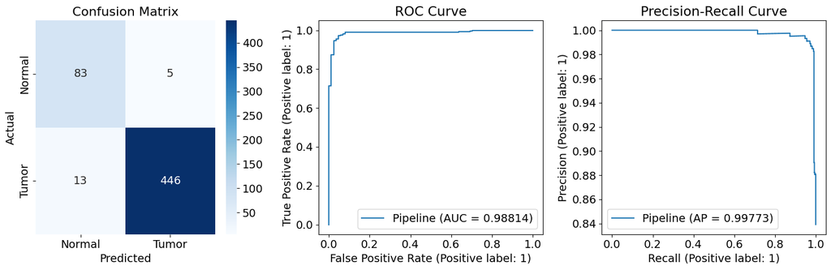

```python
plt.rcParams.update({"font.size": font_size})

fig, ax = plt.subplots(1, 3, figsize=(15, 5))

# ConfusionMatrixDisplay.from_estimator(
#     classification_pipeline,
#     X_test,
#     y_test,
#     ax=ax[0],
#     display_labels=["Normal", "Tumor"],
# )
# ax[0].set_title("Confusion Matrix")
cm = confusion_matrix(y_test, classification_pipeline.predict(X_test))

sns.heatmap(
    cm,
    annot=True,
    fmt="d",
    cmap="Blues",
    xticklabels=["Normal", "Tumor"],
    yticklabels=["Normal", "Tumor"],
    ax=ax[0],
    annot_kws={"fontsize": font_size},
)
ax[0].set_xlabel("Predicted", fontsize=font_size)
ax[0].set_ylabel("Actual", fontsize=font_size)
ax[0].set_title("Confusion Matrix", fontsize=font_size + 2)
ax[0].tick_params(axis="both", which="major", labelsize=font_size)

roc_display = RocCurveDisplay.from_estimator(
    classification_pipeline,
    X_test,
    y_test,
    ax=ax[1],
)
ax[1].set_title("ROC Curve")
roc_display.line_.set_label(f"Pipeline (AUC = {roc_display.roc_auc:.5f})")
ax[1].legend()

pr_display = PrecisionRecallDisplay.from_estimator(
    classification_pipeline,
    X_test,
    y_test,
    ax=ax[2],
)
ax[2].set_title("Precision-Recall Curve")
pr_display.line_.set_label(f"Pipeline (AP = {pr_display.average_precision:.5f})")
ax[2].legend()

plt.tight_layout()
plt.show()
```

```python
report = classification_report(y_test, classification_pipeline.predict(X_test))
print(report)
```

```
              precision    recall  f1-score   support

           0       0.86      0.94      0.90        88
           1       0.99      0.97      0.98       459

    accuracy                           0.97       547
   macro avg       0.93      0.96      0.94       547
weighted avg       0.97      0.97      0.97       547
```

#### Explainable AI analysis

To interpret our model, we will implement SHAP to determine the features of most importance. We will attempt to implement it in 3 ways

1. Explain the Classifier alone with the reduced feature set from LLE
   - This will allow us to test SHAP on out model, for LLE embeddings, this is not going to add much explainability as there is not at way to reverse the embeddings
2. Explain the whole pipeline
   - This is the ideal solution to determine what features are the most important, but due to the high dimensionality of our data, may not be possible
3. Utilize SKLearn permutation_importance
   - This implementation would use less memory and therefore be a possible way to add explainability, but also may take too much time

```python
shap.initjs()
```

```python
feature_names = X_filtered.columns
len(feature_names)
```

```
238284
```

```python
transformed_feature_names = classification_pipeline[:-1].get_feature_names_out(
    feature_names
)
transformed_feature_names
```

```
array(['locallylinearembedding0', 'locallylinearembedding1',
       'locallylinearembedding2', ..., 'locallylinearembedding1497',
       'locallylinearembedding1498', 'locallylinearembedding1499'],
      dtype=object)
```

```python
explainer = shap.LinearExplainer(
    classification_pipeline.named_steps["classifier"],
    classification_pipeline[:-1].transform(X_train),
    feature_names=transformed_feature_names,
)
```

```python
explanations = explainer(classification_pipeline[:-1].transform(X_test))
```

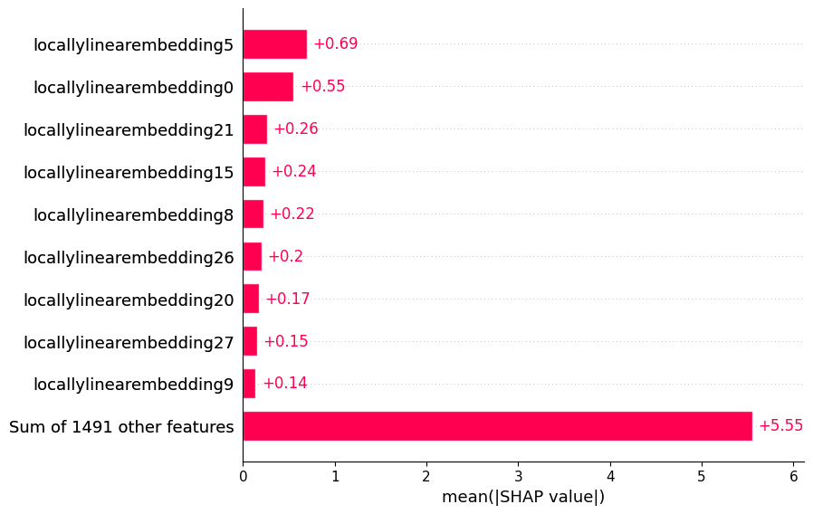

```python
shap.plots.bar(explanations)
```

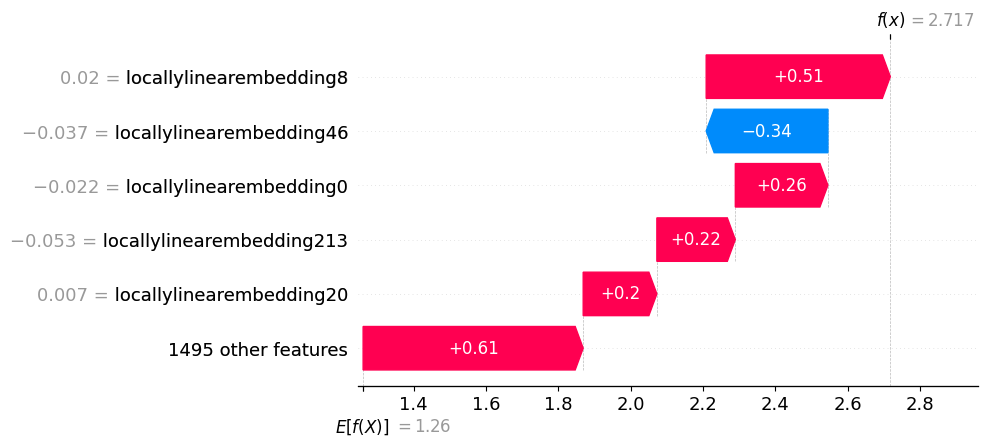

```python
shap.plots.waterfall(explanations[0], max_display=6)
```

```python
X_test[0].shape
```

```
(238284,)
```

```python
shap.sample(X_test, 100).shape
```

```
(100, 238284)
```

```python
explainer = shap.KernelExplainer(
    classification_pipeline.predict,
    shap.sample(X_test, 100),
    feature_names=feature_names,
)
```

```python
explanations = explainer(X_test[0])
```

[output not shown]

```python
from sklearn.inspection import permutation_importance

result = permutation_importance(
    classification_pipeline, X_test, y_test, n_repeats=5, random_state=RANDOM_STATE, n_jobs=20
)

# Map importance scores to original feature names
feature_importances = dict(zip(feature_names, result.importances_mean))
```

[output not shown]

[output cut: 78 more lines]

[output not shown]